```python
# Importing all important statements
import json
import matplotlib.pyplot as plt
import numpy as np
import os
import pandas as pd
import re
import requests
import seaborn as sns
import tweepy
from tweepy import OAuthHandler
from timeit import default_timer as timer

from datetime import datetime
from functools import reduce

% matplotlib inline
```

# Gathering Data

### Twitter Archive (Local File)

```python
# importing the twitter archive file
twitter1 = pd.read_csv('twitter-archive-enhanced.csv')
```

### Image prediction URL

```python
# importing the image predictions file from the Udacity website
url = 'https://d17h27t6h515a5.cloudfront.net/topher/2017/August/599fd2ad_image-predictions/image-predictions.tsv'
response = requests.get(url)
with open(os.path.join('image_predictions.tsv'), mode = 'wb') as file:
    file.write(response.content)
```

```python
# Load the image predictions file
images = pd.read_csv('image_predictions.tsv', sep = '\t')
```

### Tweets (Twitter API)

```python
#Credentials for accessing API
consumer_key = 'HIDDEN'
consumer_secret = 'HIDDEN'
access_token = 'HIDDEN'
access_secret = 'HIDDEN'


auth = OAuthHandler(consumer_key, consumer_secret)
auth.set_access_token(access_token, access_secret)
```

```python
api = tweepy.API(auth, wait_on_rate_limit=True, wait_on_rate_limit_notify=True)
```

```python
# Tweet IDs for which to gather additional data via Twitter's API
tweet_ids = twitter1.tweet_id.values
len(tweet_ids)
```

```
2356
```

```python
# Using the tweet IDs in the Twitter archive, query the Twitter API for each tweet's JSON

start = timer() # start timer

with open('getstatus_error.txt', 'w') as errfile:
    valid_ids = 0
    err_ids = 0
    tweet_ids = twitter1.tweet_id
    with open('tweet_json.txt', 'w', encoding='utf-8') as outfile:
        for i, tweet_id in tweet_ids.iteritems():
            try:
                print("%s# %s" % (str(i+1), tweet_id))
                # Get tweet data using Twitter API
                tweet = api.get_status(tweet_id, tweet_mode='extended')
                json_content = tweet._json

                # Write each tweet's JSON data to its own line in a file
                json.dump(json_content, outfile)
                outfile.write('\n')
                valid_ids += 1
            except tweepy.TweepError as e:
                err_ids += 1
                err_str = []
                err_str.append(str(tweet_id))
                err_str.append(': ')
                err_str.append(e.response.json()['errors'][0]['message'])
                err_str.append('\n')
                errfile.write(''.join(err_str))
                print(''.join(err_str))
                continue
        print("%s %s" % ('Valid tweets:', valid_ids))
        print("%s %s" % ('Error tweets:', err_ids))

end = timer() # end timer
print((end - start)/(1000*60))
```

[output not shown]

[output cut: 2344 more lines]

[output not shown]

```python
# List of dictionaries to read tweet's JSON data line by line and later convert to a DataFrame
df_list = []
with open('tweet_json.txt', 'r') as json_file:
    for line in json_file:
        status = json.loads(line)

        # Append to list of dictionaries
        df_list.append({'tweet_id': status['id'],
                        'retweet_count': status['retweet_count'],
                        'favorite_count': status['favorite_count'],
                        'display_text_range': status['display_text_range']
                       })

# Create a DataFrame with tweet ID, retweet count, favorite count and display_text_range
twitter2 = pd.DataFrame(df_list, columns = ['tweet_id', 'retweet_count', 'favorite_count', 'display_text_range'])
```

# Assessing Data

```python
twitter1.sample(3)
```

|  | tweet_id | in_reply_to_status_id | in_reply_to_user_id | timestamp | source | text | retweeted_status_id | retweeted_status_user_id | retweeted_status_timestamp | expanded_urls | rating_numerator | rating_denominator | name | doggo | floofer | pupper | puppo |
| --- | --- | --- | --- | --- | --- | --- | --- | --- | --- | --- | --- | --- | --- | --- | --- | --- | --- |
| 342 | 832088576586297345 | 8.320875e+17 | 30582082.0 | 2017-02-16 04:45:50 +0000 | <a href="http://twitter.com/download/iphone" r... | @docmisterio account started on 11/15/15 | NaN | NaN | NaN | NaN | 11 | 15 | None | None | None | None | None |
| 371 | 828408677031882754 | NaN | NaN | 2017-02-06 01:03:14 +0000 | <a href="http://twitter.com/download/iphone" r... | This is Bear. He went outside to play in the s... | NaN | NaN | NaN | https://twitter.com/dog_rates/status/828408677... | 12 | 10 | Bear | None | None | None | None |
| 2058 | 671347597085433856 | NaN | NaN | 2015-11-30 15:18:34 +0000 | <a href="http://twitter.com/download/iphone" r... | This is Lola. She was not fully prepared for t... | NaN | NaN | NaN | https://twitter.com/dog_rates/status/671347597... | 9 | 10 | Lola | None | None | None | None |

```python
twitter1.info()
```

```
<class 'pandas.core.frame.DataFrame'>
RangeIndex: 2356 entries, 0 to 2355
Data columns (total 17 columns):
tweet_id                      2356 non-null int64
in_reply_to_status_id         78 non-null float64
in_reply_to_user_id           78 non-null float64
timestamp                     2356 non-null object
source                        2356 non-null object
text                          2356 non-null object
retweeted_status_id           181 non-null float64
retweeted_status_user_id      181 non-null float64
retweeted_status_timestamp    181 non-null object
expanded_urls                 2297 non-null object
rating_numerator              2356 non-null int64
rating_denominator            2356 non-null int64
name                          2356 non-null object
doggo                         2356 non-null object
floofer                       2356 non-null object
pupper                        2356 non-null object
puppo                         2356 non-null object
dtypes: float64(4), int64(3), object(10)
memory usage: 313.0+ KB
```

```python
twitter1['tweet_id'].value_counts()
```

```
749075273010798592    1
741099773336379392    1
798644042770751489    1
825120256414846976    1
769212283578875904    1
700462010979500032    1
780858289093574656    1
699775878809702401    1
880095782870896641    1
760521673607086080    1
776477788987613185    1
691820333922455552    1
715696743237730304    1
714606013974974464    1
760539183865880579    1
```

[output cut: 47 more lines]

```python
twitter1['source'].value_counts()
```

```
<a href="http://twitter.com/download/iphone" rel="nofollow">Twitter for iPhone</a>     2221
<a href="http://vine.co" rel="nofollow">Vine - Make a Scene</a>                          91
<a href="http://twitter.com" rel="nofollow">Twitter Web Client</a>                       33
<a href="https://about.twitter.com/products/tweetdeck" rel="nofollow">TweetDeck</a>      11
Name: source, dtype: int64
```

```python
twitter1['text'].value_counts()
```

```
We normally don't rate unicorns but this one has 3 ears so it must be super rare. 12/10 majestic af https://t.co/f9qlKiv39T                                                1
This is Luna. She's just heckin precious af I have nothing else to say. 12/10 https://t.co/gQH2mmKIJW                                                                      1
This is Kingsley Wellensworth III. He owns 7 range rovers. Has a cardigan collection. Would rather be sailing. 9/10 https://t.co/BE4ahQ0IO2                                1
This is Wallace. He'll be your chau-fur this evening. 12/10 eyes on the road Wallace https://t.co/p1RD39XjUe                                                               1
This is Marley. She's having a ruff day. Pretty pupset. 12/10 would assist https://t.co/yLm7hQ6UXh                                                                         1
That is Quizno. This is his beach. He does not tolerate human shenanigans on his beach. 10/10 reclaim ur land doggo https://t.co/vdr7DaRSa7                                1
This guy's dog broke. So sad. 9/10 would still pet https://t.co/BYiXJDEzv7                                                                                                 1
Jack deserves another round of applause. If you missed this earlier today I strongly suggest reading it. Wonderful first 14/10 🐶❤️                                         1
There's a lot going on here but in my honest opinion every dog pictured is pretty fabulous. 10/10 for all. Good dogs https://t.co/VvYVbsi6c3                               1
This is Bentley. It's his first time going to the beach. I think he's a fan. 12/10 would build sand castles with https://t.co/iDK4OyQJoy                                   1
Meet Dug. Dug fucken loves peaches. 8/10 https://t.co/JtA1TG21Xx                                                                                                           1
RT @dog_rates: This is Tyrone. He's a leaf wizard. Self-motivated. No eyes (tragic). Inspirational af. 11/10 enthusiasm is tangible https:/…                               1
This is Frank (pronounced "Fronq"). Too many boxing gloves, not enough passion. Frank is a lover not a fighter. 8/10 https://t.co/CpPxD28IpV                               1
Ok, I'll admit this is a pretty adorable bunny hopping towards the ocean but please only send in dogs... 11/10 https://t.co/sfsVCGIipI                                     1
This is Ronnie. He hopes you're having a great day. Nifty tongue slip. 12/10 would pat head approvingly https://t.co/4fY2bsAm65                                            1
This is Dewey (pronounced "covfefe"). He's having a good walk. Arguably the best walk. 13/10 would snug softly https://t.co/HciEaJkC4D                                     1
Two sneaky puppers were not initially seen, moving the rating to 143/130. Please forgive us. Thank you https://t.co/kRK51Y5ac3                                             1
This is Chaz. He's an X Games half pipe superstar. 6 gold medals. Lost back legs saving a baby from a tornado 12/10 https://t.co/uxdOfblUB0                                1
This is Phineas. He's a magical dog. Only appears through the hole of a donut. 10/10 mysterious pup https://t.co/NECxEHN5YU                                                1
This is Kial. Kial is either wearing a cape, which would be rad, or flashing us, which would be rude. 10/10 or 4/10 https://t.co/8zcwIoiuqR                                1
I would do radical things in the name of Dog God. I'd believe every word in that book. 10/10 https://t.co/9ZuGAmLZDR                                                       1
This is Rumpole. He'll be your Uber driver this evening. Won't start driving until you buckle pup. 13/10 h*ckin safe good boy https://t.co/EX9Z3EXlVP                      1
This is Olaf. He's gotta be rare. Seems sturdy. Tail is floofy af. 12/10 would do whatever it takes to pet https://t.co/E9jaU59bh9                                         1
Here we are witnessing an isolated squad of bouncing doggos. Unbelievably rare for this time of year. 11/10 for all https://t.co/CCdlwiTwQf                                1
This is Sweets the English Bulldog. Waves back to other bikers. 12/10 just a fantastic friendly pupper https://t.co/WYiFzuX7D4                                             1
This is Tyrone. He's a leaf wizard. Self-motivated. No eyes (tragic). Inspirational af. 11/10 enthusiasm is tangible https://t.co/pRp1Npucbz                               1
Say hello to Eugene &amp; Patti Melt. No matter how dysfunctional they get, they will never top their owners. Both 12/10 would pet at same time https://t.co/jQUdvtdYMu    1
```

[output cut: 35 more lines]

```python
twitter1['retweeted_status_id'].value_counts()
```

```
7.757333e+17    1
7.507196e+17    1
6.742918e+17    1
6.833919e+17    1
8.269587e+17    1
8.780576e+17    1
7.320056e+17    1
7.186315e+17    1
6.732953e+17    1
7.914070e+17    1
8.447048e+17    1
7.862340e+17    1
8.685523e+17    1
7.504293e+17    1
8.327664e+17    1
6.690004e+17    1
6.873173e+17    1
7.638376e+17    1
7.815247e+17    1
8.092201e+17    1
8.000650e+17    1
8.174239e+17    1
8.001414e+17    1
7.909461e+17    1
7.867091e+17    1
8.406323e+17    1
8.688804e+17    1
7.869631e+17    1
7.733088e+17    1
8.222448e+17    1
               ..
6.816941e+17    1
7.899865e+17    1
7.939622e+17    1
6.800555e+17    1
7.128090e+17    1
8.164506e+17    1
6.769365e+17    1
6.675487e+17    1
8.083449e+17    1
7.626999e+17    1
6.678667e+17    1
8.479710e+17    1
6.820881e+17    1
8.352641e+17    1
7.761133e+17    1
7.902771e+17    1
6.675484e+17    1
7.677549e+17    1
8.782815e+17    1
8.663350e+17    1
7.399792e+17    1
7.403732e+17    1
8.395493e+17    1
7.001438e+17    1
8.482894e+17    1
7.848260e+17    1
7.806013e+17    1
8.305833e+17    1
7.047611e+17    1
7.331095e+17    1
Name: retweeted_status_id, Length: 181, dtype: int64
```

```python
twitter1['retweeted_status_user_id'].value_counts()
```

```
4.196984e+09    156
4.296832e+09      2
5.870972e+07      1
6.669901e+07      1
4.119842e+07      1
7.475543e+17      1
7.832140e+05      1
7.266347e+08      1
4.871977e+08      1
5.970642e+08      1
4.466750e+07      1
1.228326e+09      1
7.992370e+07      1
2.488557e+07      1
7.874618e+17      1
3.638908e+08      1
5.128045e+08      1
8.117408e+08      1
1.732729e+09      1
1.960740e+07      1
1.547674e+08      1
3.410211e+08      1
7.124572e+17      1
2.804798e+08      1
1.950368e+08      1
Name: retweeted_status_user_id, dtype: int64
```

```python
twitter1['retweeted_status_timestamp'].value_counts()
```

```
2016-10-21 18:16:44 +0000    1
2016-10-23 19:42:02 +0000    1
2016-02-26 02:20:37 +0000    1
2017-07-15 02:44:07 +0000    1
2015-12-08 18:17:56 +0000    1
2016-07-12 18:27:35 +0000    1
2017-02-08 17:00:26 +0000    1
2017-02-09 01:27:41 +0000    1
2016-09-14 17:40:06 +0000    1
2015-12-29 04:31:49 +0000    1
2017-05-21 16:48:45 +0000    1
2016-10-14 16:13:10 +0000    1
2015-12-02 03:40:57 +0000    1
2017-02-12 01:04:29 +0000    1
2017-02-16 23:23:38 +0000    1
2016-11-01 03:00:09 +0000    1
2016-11-22 00:10:52 +0000    1
2016-11-02 23:45:19 +0000    1
2016-01-25 00:26:41 +0000    1
2016-06-25 17:31:25 +0000    1
2016-02-12 17:22:12 +0000    1
2017-01-13 17:00:21 +0000    1
2016-09-22 20:33:42 +0000    1
2016-10-03 15:42:44 +0000    1
2017-01-14 17:00:24 +0000    1
2017-01-02 18:38:42 +0000    1
2017-06-23 01:10:23 +0000    1
2016-02-21 01:19:47 +0000    1
2016-10-13 23:23:56 +0000    1
2015-11-19 01:27:25 +0000    1
                            ..
2015-12-24 16:00:30 +0000    1
2015-12-11 16:40:19 +0000    1
2016-03-21 19:29:52 +0000    1
2016-08-01 01:28:46 +0000    1
2017-01-11 02:21:57 +0000    1
2016-01-13 16:56:30 +0000    1
2017-04-24 02:13:14 +0000    1
2017-02-18 01:39:12 +0000    1
2016-10-02 23:23:04 +0000    1
2016-08-01 16:42:51 +0000    1
2017-05-05 18:36:06 +0000    1
2017-04-01 21:42:03 +0000    1
2016-02-02 23:52:22 +0000    1
2016-09-13 16:30:07 +0000    1
2015-11-27 19:11:49 +0000    1
2016-01-03 05:11:12 +0000    1
2016-06-04 23:31:25 +0000    1
2017-03-08 18:52:12 +0000    1
2015-12-12 02:23:01 +0000    1
2016-05-19 01:38:16 +0000    1
2016-03-01 20:11:59 +0000    1
2016-06-08 02:41:38 +0000    1
2016-08-04 01:03:17 +0000    1
2016-08-08 01:44:46 +0000    1
2016-02-18 02:24:13 +0000    1
2016-12-07 22:38:52 +0000    1
2016-11-19 19:55:41 +0000    1
2016-03-20 23:23:54 +0000    1
2016-09-07 15:44:53 +0000    1
2017-05-18 01:17:25 +0000    1
Name: retweeted_status_timestamp, Length: 181, dtype: int64
```

```python
twitter1['expanded_urls'].value_counts()
```

```
https://twitter.com/dog_rates/status/667138269671505920/photo/1                                                                                                                                                                                                    2
https://www.gofundme.com/help-lorenzo-beat-cancer,https://twitter.com/dog_rates/status/860563773140209665/photo/1,https://twitter.com/dog_rates/status/860563773140209665/photo/1                                                                                  2
https://twitter.com/dog_rates/status/817827839487737858/video/1                                                                                                                                                                                                    2
https://www.loveyourmelon.com/pages/ourstory,https://twitter.com/dog_rates/status/820314633777061888/photo/1,https://twitter.com/dog_rates/status/820314633777061888/photo/1,https://twitter.com/dog_rates/status/820314633777061888/photo/1                       2
https://www.gofundme.com/3hgsuu0,https://twitter.com/dog_rates/status/840632337062862849/photo/1                                                                                                                                                                   2
https://twitter.com/dog_rates/status/669000397445533696/photo/1                                                                                                                                                                                                    2
https://twitter.com/dog_rates/status/774314403806253056/photo/1,https://twitter.com/dog_rates/status/774314403806253056/photo/1,https://twitter.com/dog_rates/status/774314403806253056/photo/1,https://twitter.com/dog_rates/status/774314403806253056/photo/1    2
https://www.gofundme.com/3ti3nps,https://twitter.com/dog_rates/status/868552278524837888/photo/1,https://twitter.com/dog_rates/status/868552278524837888/photo/1                                                                                                   2
https://twitter.com/dog_rates/status/700747788515020802/photo/1                                                                                                                                                                                                    2
https://www.gofundme.com/lolas-life-saving-surgery-funds,https://twitter.com/dog_rates/status/835264098648616962/photo/1,https://twitter.com/dog_rates/status/835264098648616962/photo/1                                                                           2
https://twitter.com/dog_rates/status/866450705531457537/photo/1,https://twitter.com/dog_rates/status/866450705531457537/photo/1                                                                                                                                    2
https://twitter.com/dog_rates/status/666104133288665088/photo/1                                                                                                                                                                                                    2
https://www.gofundme.com/surgeryforjacktheminpin,https://twitter.com/dog_rates/status/815990720817401858/photo/1                                                                                                                                                   2
https://twitter.com/dog_rates/status/680055455951884288/photo/1                                                                                                                                                                                                    2
https://twitter.com/dog_rates/status/700143752053182464/photo/1                                                                                                                                                                                                    2
https://twitter.com/dog_rates/status/762699858130116608/photo/1                                                                                                                                                                                                    2
https://twitter.com/dog_rates/status/759447681597108224/photo/1                                                                                                                                                                                                    2
https://twitter.com/dog_rates/status/676936541936185344/photo/1                                                                                                                                                                                                    2
```

[output cut: 44 more lines]

```python
twitter1['rating_numerator'].value_counts()
```

```
12      558
11      464
10      461
13      351
9       158
8       102
7        55
14       54
5        37
6        32
3        19
4        17
1         9
2         9
420       2
```

[output cut: 26 more lines]

```python
twitter1['rating_denominator'].value_counts()
```

```
10     2333
11        3
50        3
80        2
20        2
2         1
16        1
40        1
70        1
15        1
90        1
110       1
120       1
130       1
150       1
170       1
7         1
0         1
Name: rating_denominator, dtype: int64
```

```python
twitter1['name'].value_counts()
```

```
None           745
a               55
Charlie         12
Lucy            11
Cooper          11
Oliver          11
Penny           10
Tucker          10
Lola            10
Winston          9
Bo               9
the              8
Sadie            8
Bailey           7
Daisy            7
an               7
Buddy            7
Toby             7
Rusty            6
Jack             6
Leo              6
Koda             6
Jax              6
Milo             6
Bella            6
Oscar            6
Dave             6
Stanley          6
Scout            6
Sammy            5
              ...
Jeffri           1
Fido             1
Billy            1
Tassy            1
Andru            1
Daniel           1
Shikha           1
Bookstore        1
Chaz             1
infuriating      1
Champ            1
Sobe             1
Frönq            1
Stormy           1
William          1
Kial             1
Alejandro        1
Ralf             1
Mosby            1
Lipton           1
Kathmandu        1
Kendall          1
Gustaf           1
Eleanor          1
by               1
Ricky            1
Sunshine         1
Eevee            1
Ed               1
Dylan            1
Name: name, Length: 957, dtype: int64
```

```python
twitter1['doggo'].value_counts()
```

```
None     2259
doggo      97
Name: doggo, dtype: int64
```

```python
twitter1['floofer'].value_counts()
```

```
None       2346
floofer      10
Name: floofer, dtype: int64
```

```python
twitter1['pupper'].value_counts()
```

```
None      2099
pupper     257
Name: pupper, dtype: int64
```

```python
twitter1['puppo'].value_counts()
```

```
None     2326
puppo      30
Name: puppo, dtype: int64
```

```python
twitter1.loc[(twitter1[['doggo', 'floofer', 'pupper', 'puppo']] != 'None'
              ).sum(axis=1)>1]
```

|  | tweet_id | in_reply_to_status_id | in_reply_to_user_id | timestamp | source | text | retweeted_status_id | retweeted_status_user_id | retweeted_status_timestamp | expanded_urls | rating_numerator | rating_denominator | name | doggo | floofer | pupper | puppo |
| --- | --- | --- | --- | --- | --- | --- | --- | --- | --- | --- | --- | --- | --- | --- | --- | --- | --- |
| 191 | 855851453814013952 | NaN | NaN | 2017-04-22 18:31:02 +0000 | <a href="http://twitter.com/download/iphone" r... | Here's a puppo participating in the #ScienceMa... | NaN | NaN | NaN | https://twitter.com/dog_rates/status/855851453... | 13 | 10 | None | doggo | None | None | puppo |
| 200 | 854010172552949760 | NaN | NaN | 2017-04-17 16:34:26 +0000 | <a href="http://twitter.com/download/iphone" r... | At first I thought this was a shy doggo, but i... | NaN | NaN | NaN | https://twitter.com/dog_rates/status/854010172... | 11 | 10 | None | doggo | floofer | None | None |
| 460 | 817777686764523521 | NaN | NaN | 2017-01-07 16:59:28 +0000 | <a href="http://twitter.com/download/iphone" r... | This is Dido. She's playing the lead role in "... | NaN | NaN | NaN | https://twitter.com/dog_rates/status/817777686... | 13 | 10 | Dido | doggo | None | pupper | None |
| 531 | 808106460588765185 | NaN | NaN | 2016-12-12 00:29:28 +0000 | <a href="http://twitter.com/download/iphone" r... | Here we have Burke (pupper) and Dexter (doggo)... | NaN | NaN | NaN | https://twitter.com/dog_rates/status/808106460... | 12 | 10 | None | doggo | None | pupper | None |
| 565 | 802265048156610565 | 7.331095e+17 | 4.196984e+09 | 2016-11-25 21:37:47 +0000 | <a href="http://twitter.com/download/iphone" r... | Like doggo, like pupper version 2. Both 11/10 ... | NaN | NaN | NaN | https://twitter.com/dog_rates/status/802265048... | 11 | 10 | None | doggo | None | pupper | None |
| 575 | 801115127852503040 | NaN | NaN | 2016-11-22 17:28:25 +0000 | <a href="http://twitter.com/download/iphone" r... | This is Bones. He's being haunted by another d... | NaN | NaN | NaN | https://twitter.com/dog_rates/status/801115127... | 12 | 10 | Bones | doggo | None | pupper | None |
| 705 | 785639753186217984 | NaN | NaN | 2016-10-11 00:34:48 +0000 | <a href="http://twitter.com/download/iphone" r... | This is Pinot. He's a sophisticated doggo. You... | NaN | NaN | NaN | https://twitter.com/dog_rates/status/785639753... | 10 | 10 | Pinot | doggo | None | pupper | None |
| 733 | 781308096455073793 | NaN | NaN | 2016-09-29 01:42:20 +0000 | <a href="http://vine.co" rel="nofollow">Vine -... | Pupper butt 1, Doggo 0. Both 12/10 https://t.c... | NaN | NaN | NaN | https://vine.co/v/5rgu2Law2ut | 12 | 10 | None | doggo | None | pupper | None |
| 778 | 775898661951791106 | NaN | NaN | 2016-09-14 03:27:11 +0000 | <a href="http://twitter.com/download/iphone" r... | RT @dog_rates: Like father (doggo), like son (... | 7.331095e+17 | 4.196984e+09 | 2016-05-19 01:38:16 +0000 | https://twitter.com/dog_rates/status/733109485... | 12 | 10 | None | doggo | None | pupper | None |
| 822 | 770093767776997377 | NaN | NaN | 2016-08-29 03:00:36 +0000 | <a href="http://twitter.com/download/iphone" r... | RT @dog_rates: This is just downright precious... | 7.410673e+17 | 4.196984e+09 | 2016-06-10 00:39:48 +0000 | https://twitter.com/dog_rates/status/741067306... | 12 | 10 | just | doggo | None | pupper | None |
| 889 | 759793422261743616 | NaN | NaN | 2016-07-31 16:50:42 +0000 | <a href="http://twitter.com/download/iphone" r... | Meet Maggie &amp; Lila. Maggie is the doggo, L... | NaN | NaN | NaN | https://twitter.com/dog_rates/status/759793422... | 12 | 10 | Maggie | doggo | None | pupper | None |
| 956 | 751583847268179968 | NaN | NaN | 2016-07-09 01:08:47 +0000 | <a href="http://twitter.com/download/iphone" r... | Please stop sending it pictures that don't eve... | NaN | NaN | NaN | https://twitter.com/dog_rates/status/751583847... | 5 | 10 | None | doggo | None | pupper | None |
| 1063 | 741067306818797568 | NaN | NaN | 2016-06-10 00:39:48 +0000 | <a href="http://twitter.com/download/iphone" r... | This is just downright precious af. 12/10 for ... | NaN | NaN | NaN | https://twitter.com/dog_rates/status/741067306... | 12 | 10 | just | doggo | None | pupper | None |
| 1113 | 733109485275860992 | NaN | NaN | 2016-05-19 01:38:16 +0000 | <a href="http://twitter.com/download/iphone" r... | Like father (doggo), like son (pupper). Both 1... | NaN | NaN | NaN | https://twitter.com/dog_rates/status/733109485... | 12 | 10 | None | doggo | None | pupper | None |

```python
twitter1.loc[twitter1['name'].str.isupper()]
```

|  | tweet_id | in_reply_to_status_id | in_reply_to_user_id | timestamp | source | text | retweeted_status_id | retweeted_status_user_id | retweeted_status_timestamp | expanded_urls | rating_numerator | rating_denominator | name | doggo | floofer | pupper | puppo |
| --- | --- | --- | --- | --- | --- | --- | --- | --- | --- | --- | --- | --- | --- | --- | --- | --- | --- |
| 775 | 776201521193218049 | NaN | NaN | 2016-09-14 23:30:38 +0000 | <a href="http://twitter.com/download/iphone" r... | This is O'Malley. That is how he sleeps. Doesn... | NaN | NaN | NaN | https://twitter.com/dog_rates/status/776201521... | 10 | 10 | O | None | None | None | None |
| 2041 | 671542985629241344 | NaN | NaN | 2015-12-01 04:14:59 +0000 | <a href="http://twitter.com/download/iphone" r... | This is JD (stands for "just dog"). He's like ... | NaN | NaN | NaN | https://twitter.com/dog_rates/status/671542985... | 10 | 10 | JD | None | None | None | None |

```python
twitter2.sample(5)
```

|  | tweet_id | retweet_count | favorite_count | display_text_range |
| --- | --- | --- | --- | --- |
| 1493 | 691416866452082688 | 8049 | 20019 | [0, 107] |
| 2297 | 666649482315059201 | 615 | 1103 | [0, 138] |
| 1161 | 719367763014393856 | 774 | 2871 | [0, 142] |
| 2133 | 669680153564442624 | 294 | 667 | [0, 139] |
| 450 | 817423860136083457 | 16091 | 35930 | [0, 56] |

```python
twitter2.info()
```

```
<class 'pandas.core.frame.DataFrame'>
RangeIndex: 2337 entries, 0 to 2336
Data columns (total 4 columns):
tweet_id              2337 non-null int64
retweet_count         2337 non-null int64
favorite_count        2337 non-null int64
display_text_range    2337 non-null object
dtypes: int64(3), object(1)
memory usage: 73.1+ KB
```

```python
twitter2['tweet_id'].value_counts()
```

```
749075273010798592    1
741099773336379392    1
798644042770751489    1
825120256414846976    1
769212283578875904    1
700462010979500032    1
780858289093574656    1
699775878809702401    1
880095782870896641    1
760521673607086080    1
776477788987613185    1
691820333922455552    1
715696743237730304    1
714606013974974464    1
760539183865880579    1
```

[output cut: 47 more lines]

```python
twitter2['favorite_count'].value_counts()
```

```
0         166
1431        4
329         4
1114        4
1850        3
236         3
8367        3
2316        3
3394        3
121         3
1430        3
243         3
441         3
2739        3
720         3
```

[output cut: 47 more lines]

```python
twitter2['retweet_count'].value_counts()
```

```
477      6
245      5
501      5
443      4
57       4
589      4
1001     4
127      4
596      4
566      4
394      4
88       4
65       4
2067     4
1571     4
```

[output cut: 47 more lines]

```python
images.sample(5)
```

|  | tweet_id | jpg_url | img_num | p1 | p1_conf | p1_dog | p2 | p2_conf | p2_dog | p3 | p3_conf | p3_dog |
| --- | --- | --- | --- | --- | --- | --- | --- | --- | --- | --- | --- | --- |
| 1448 | 776113305656188928 | https://pbs.twimg.com/media/CsVO7ljW8AAckRD.jpg | 1 | mousetrap | 0.777468 | False | black_widow | 0.093940 | False | paddlewheel | 0.017492 | False |
| 1332 | 757725642876129280 | https://pbs.twimg.com/media/CoP7c4bWcAAr55g.jpg | 2 | seat_belt | 0.425176 | False | Labrador_retriever | 0.128128 | True | Siamese_cat | 0.091241 | False |
| 600 | 679736210798047232 | https://pbs.twimg.com/media/CW7oelWWcAAhyzz.jpg | 1 | French_bulldog | 0.319139 | True | Chihuahua | 0.154088 | True | Cardigan | 0.117688 | True |
| 1752 | 824325613288833024 | https://pbs.twimg.com/media/C3CXxaoWQAAiLuC.jpg | 1 | Pembroke | 0.990793 | True | Cardigan | 0.008919 | True | basenji | 0.000262 | True |
| 776 | 689661964914655233 | https://pbs.twimg.com/media/CZIr5gFUsAAvnif.jpg | 1 | Italian_greyhound | 0.322818 | True | whippet | 0.246966 | True | Chihuahua | 0.122541 | True |

```python
images.info()
```

```
<class 'pandas.core.frame.DataFrame'>
RangeIndex: 2075 entries, 0 to 2074
Data columns (total 12 columns):
tweet_id    2075 non-null int64
jpg_url     2075 non-null object
img_num     2075 non-null int64
p1          2075 non-null object
p1_conf     2075 non-null float64
p1_dog      2075 non-null bool
p2          2075 non-null object
p2_conf     2075 non-null float64
p2_dog      2075 non-null bool
p3          2075 non-null object
p3_conf     2075 non-null float64
p3_dog      2075 non-null bool
dtypes: bool(3), float64(3), int64(2), object(4)
memory usage: 152.1+ KB
```

```python
images['tweet_id'].value_counts()
```

```
685532292383666176    1
826598365270007810    1
692158366030913536    1
714606013974974464    1
715696743237730304    1
776477788987613185    1
772114945936949249    1
699775878809702401    1
780858289093574656    1
700462010979500032    1
732726085725589504    1
738883359779196928    1
798644042770751489    1
743510151680958465    1
837012587749474308    1
```

[output cut: 47 more lines]

```python
images['jpg_url'].value_counts()
```

```
https://pbs.twimg.com/media/CvJCabcWgAIoUxW.jpg                                            2
https://pbs.twimg.com/media/Co-hmcYXYAASkiG.jpg                                            2
https://pbs.twimg.com/ext_tw_video_thumb/807106774843039744/pu/img/8XZg1xW35Xp2J6JW.jpg    2
https://pbs.twimg.com/media/CmoPdmHW8AAi8BI.jpg                                            2
https://pbs.twimg.com/media/CiibOMzUYAA9Mxz.jpg                                            2
https://pbs.twimg.com/media/Ct72q9jWcAAhlnw.jpg                                            2
https://pbs.twimg.com/media/CwiuEJmW8AAZnit.jpg                                            2
https://pbs.twimg.com/media/Cs_DYr1XEAA54Pu.jpg                                            2
https://pbs.twimg.com/media/CsVO7ljW8AAckRD.jpg                                            2
https://pbs.twimg.com/media/CWza7kpWcAAdYLc.jpg                                            2
https://pbs.twimg.com/media/CvoBPWRWgAA4het.jpg                                            2
https://pbs.twimg.com/media/Ct2qO5PXEAE6eB0.jpg                                            2
https://pbs.twimg.com/media/CV_cnjHWUAADc-c.jpg                                            2
https://pbs.twimg.com/media/CUN4Or5UAAAa5K4.jpg                                            2
https://pbs.twimg.com/media/CvyVxQRWEAAdSZS.jpg                                            2
https://pbs.twimg.com/media/CU3mITUWIAAfyQS.jpg                                            2
https://pbs.twimg.com/media/Cwx99rpW8AMk_Ie.jpg                                            2
https://pbs.twimg.com/media/CtzKC7zXEAALfSo.jpg                                            2
https://pbs.twimg.com/media/Crwxb5yWgAAX5P_.jpg                                            2
https://pbs.twimg.com/media/C4KHj-nWQAA3poV.jpg                                            2
https://pbs.twimg.com/media/C3nygbBWQAAjwcW.jpg                                            2
https://pbs.twimg.com/media/CeRoBaxWEAABi0X.jpg                                            2
https://pbs.twimg.com/ext_tw_video_thumb/675354114423808004/pu/img/qL1R_nGLqa6lmkOx.jpg    2
https://pbs.twimg.com/media/CwS4aqZXUAAe3IO.jpg                                            2
https://pbs.twimg.com/media/CkNjahBXAAQ2kWo.jpg                                            2
https://pbs.twimg.com/media/CdHwZd0VIAA4792.jpg                                            2
https://pbs.twimg.com/media/CsrjryzWgAAZY00.jpg                                            2
https://pbs.twimg.com/media/DA7iHL5U0AA1OQo.jpg                                            2
https://pbs.twimg.com/media/CcG07BYW0AErrC9.jpg                                            2
https://pbs.twimg.com/media/CW88XN4WsAAlo8r.jpg                                            2
                                                                                          ..
https://pbs.twimg.com/media/CZRBZ9mWkAAWblt.jpg                                            1
https://pbs.twimg.com/media/CquFrCKWAAAr32m.jpg                                            1
https://pbs.twimg.com/media/CoLTbbzXYAElNM6.jpg                                            1
https://pbs.twimg.com/media/C59VqMUXEAAzldG.jpg                                            1
https://pbs.twimg.com/media/CXw2jSpWMAAad6V.jpg                                            1
https://pbs.twimg.com/media/CT5m4VGWEAAtKc8.jpg                                            1
https://pbs.twimg.com/media/CUxLJO8U8AAu6Zu.jpg                                            1
https://pbs.twimg.com/media/CeMWubMWwAA6GwF.jpg                                            1
https://pbs.twimg.com/media/CeHWFksXIAAyypp.jpg                                            1
https://pbs.twimg.com/ext_tw_video_thumb/685663358637486080/pu/img/3cXSHFZAgJQ_dDCf.jpg    1
https://pbs.twimg.com/media/C2EONHNWQAUWxkP.jpg                                            1
https://pbs.twimg.com/media/CYFlVUFWwAAEsWX.jpg                                            1
https://pbs.twimg.com/media/CdJnJ1dUEAARNcf.jpg                                            1
https://pbs.twimg.com/media/CiTEFjDXAAAqU6I.jpg                                            1
https://pbs.twimg.com/media/CW9a_h1WwAApmAy.jpg                                            1
https://pbs.twimg.com/media/ChQRsYaW0AETD7z.jpg                                            1
https://pbs.twimg.com/media/CV56f54WsAEv4kJ.jpg                                            1
https://pbs.twimg.com/media/C1qi26rW8AMaj9K.jpg                                            1
https://pbs.twimg.com/ext_tw_video_thumb/805826823359631360/pu/img/yr_fF0TZCR-B70p2.jpg    1
https://pbs.twimg.com/media/DD-40X3WAAAJPU5.jpg                                            1
https://pbs.twimg.com/media/CrJjdZmXgAEWLSD.jpg                                            1
https://pbs.twimg.com/media/CfN23ArXEAEkZkz.jpg                                            1
https://pbs.twimg.com/media/DFHDQBbXgAEqY7t.jpg                                            1
https://pbs.twimg.com/media/CpdfpzKWYAAWSUi.jpg                                            1
https://pbs.twimg.com/media/Coz12OLWgAADdys.jpg                                            1
https://pbs.twimg.com/media/C20HmaKWgAQ6-6X.jpg                                            1
https://pbs.twimg.com/media/DFTH_O-UQAACu20.jpg                                            1
https://pbs.twimg.com/media/C5d0QtvXMAI_7uz.jpg                                            1
https://pbs.twimg.com/media/CUOYBbbWIAAXQGU.jpg                                            1
https://pbs.twimg.com/media/DCIgSR0XgAANEOY.jpg                                            1
Name: jpg_url, Length: 2009, dtype: int64
```

```python
images['img_num'].value_counts()
```

```
1    1780
2     198
3      66
4      31
Name: img_num, dtype: int64
```

```python
images['p1'].value_counts()
```

```
golden_retriever             150
Labrador_retriever           100
Pembroke                      89
Chihuahua                     83
pug                           57
chow                          44
Samoyed                       43
toy_poodle                    39
Pomeranian                    38
cocker_spaniel                30
malamute                      30
French_bulldog                26
Chesapeake_Bay_retriever      23
miniature_pinscher            23
seat_belt                     22
German_shepherd               20
Siberian_husky                20
Staffordshire_bullterrier     20
Cardigan                      19
web_site                      19
beagle                        18
Maltese_dog                   18
Eskimo_dog                    18
Shetland_sheepdog             18
teddy                         18
Rottweiler                    17
Shih-Tzu                      17
Lakeland_terrier              17
kuvasz                        16
Italian_greyhound             16
                            ...
crane                          1
clumber                        1
damselfly                      1
cowboy_boot                    1
mortarboard                    1
bee_eater                      1
African_grey                   1
earthstar                      1
espresso                       1
sliding_door                   1
ice_lolly                      1
remote_control                 1
panpipe                        1
bearskin                       1
flamingo                       1
fountain                       1
king_penguin                   1
leopard                        1
hare                           1
carton                         1
dhole                          1
coil                           1
conch                          1
alp                            1
stove                          1
beaver                         1
marmot                         1
radio_telescope                1
Egyptian_cat                   1
zebra                          1
Name: p1, Length: 378, dtype: int64
```

```python
images['p1_conf'].value_counts()
```

```
0.366248    2
0.713293    2
0.375098    2
0.636169    2
0.611525    2
0.420463    2
0.581403    2
0.403698    2
0.530104    2
0.254856    2
0.346545    2
0.721188    2
0.677408    2
0.907083    2
0.243529    2
0.505370    2
0.593858    2
0.372202    2
0.274637    2
0.600276    2
0.506312    2
0.615163    2
0.556595    2
0.995143    2
0.809197    2
0.964929    2
0.777468    2
0.336200    2
0.617389    2
0.786089    2
           ..
0.483228    1
0.556524    1
0.176423    1
0.318981    1
0.733025    1
0.730152    1
0.436023    1
0.479008    1
0.162935    1
0.897162    1
0.320420    1
0.999833    1
0.995873    1
0.523206    1
0.942911    1
0.537652    1
0.672791    1
0.952258    1
0.855959    1
0.665578    1
0.841265    1
0.668164    1
0.946828    1
0.714719    1
0.352946    1
0.713102    1
0.765266    1
0.491022    1
0.905334    1
1.000000    1
Name: p1_conf, Length: 2006, dtype: int64
```

```python
images['p1_dog'].value_counts()
```

```
True     1532
False     543
Name: p1_dog, dtype: int64
```

```python
images['p2'].value_counts()
```

```
Labrador_retriever                104
golden_retriever                   92
Cardigan                           73
Chihuahua                          44
Pomeranian                         42
French_bulldog                     41
Chesapeake_Bay_retriever           41
toy_poodle                         37
cocker_spaniel                     34
Siberian_husky                     33
miniature_poodle                   33
beagle                             28
Eskimo_dog                         27
collie                             27
Pembroke                           27
kuvasz                             26
Italian_greyhound                  22
American_Staffordshire_terrier     21
Pekinese                           21
miniature_pinscher                 20
chow                               20
malinois                           20
Samoyed                            20
toy_terrier                        20
Norwegian_elkhound                 19
Boston_bull                        19
Staffordshire_bullterrier          18
pug                                17
Irish_terrier                      17
kelpie                             16
                                 ...
standard_schnauzer                  1
ashcan                              1
shower_cap                          1
toucan                              1
folding_chair                       1
ice_lolly                           1
drake                               1
table_lamp                          1
peacock                             1
triceratops                         1
brown_bear                          1
lesser_panda                        1
promontory                          1
sarong                              1
volcano                             1
bathing_cap                         1
Madagascar_cat                      1
Japanese_spaniel                    1
EntleBucher                         1
coral_reef                          1
bucket                              1
water_buffalo                       1
rule                                1
hyena                               1
cockroach                           1
barracouta                          1
minibus                             1
spotlight                           1
sliding_door                        1
hatchet                             1
Name: p2, Length: 405, dtype: int64
```

```python
images['p2_conf'].value_counts()
```

```
0.069362    3
0.027907    2
0.193654    2
0.271929    2
0.003143    2
0.197021    2
0.347609    2
0.151047    2
0.052724    2
0.153126    2
0.119256    2
0.227150    2
0.057091    2
0.149950    2
0.025119    2
0.165930    2
0.190503    2
0.012763    2
0.181351    2
0.325106    2
0.020089    2
0.172844    2
0.142204    2
0.152445    2
0.052956    2
0.099984    2
0.093940    2
0.252706    2
0.140798    2
0.130611    2
           ..
0.083513    1
0.100988    1
0.038062    1
0.317368    1
0.256433    1
0.057883    1
0.098354    1
0.250014    1
0.088474    1
0.178088    1
0.053008    1
0.052396    1
0.165655    1
0.182538    1
0.074962    1
0.120530    1
0.169758    1
0.119745    1
0.090938    1
0.071665    1
0.139346    1
0.036575    1
0.073101    1
0.118181    1
0.000077    1
0.138331    1
0.254884    1
0.090644    1
0.219323    1
0.016301    1
Name: p2_conf, Length: 2004, dtype: int64
```

```python
images['p2_dog'].value_counts()
```

```
True     1553
False     522
Name: p2_dog, dtype: int64
```

```python
images['p3'].value_counts()
```

```
Labrador_retriever                79
Chihuahua                         58
golden_retriever                  48
Eskimo_dog                        38
kelpie                            35
kuvasz                            34
Staffordshire_bullterrier         32
chow                              32
cocker_spaniel                    31
beagle                            31
Pomeranian                        29
toy_poodle                        29
Pekinese                          29
Chesapeake_Bay_retriever          27
Great_Pyrenees                    27
Pembroke                          27
French_bulldog                    26
malamute                          26
American_Staffordshire_terrier    24
Cardigan                          23
pug                               23
basenji                           21
toy_terrier                       20
bull_mastiff                      20
Siberian_husky                    19
Shetland_sheepdog                 17
Boston_bull                       17
doormat                           16
Lakeland_terrier                  16
boxer                             16
                                  ..
can_opener                         1
seashore                           1
broccoli                           1
cardoon                            1
cuirass                            1
brown_bear                         1
theater_curtain                    1
acorn                              1
pot                                1
jersey                             1
chime                              1
hand_blower                        1
barrow                             1
stinkhorn                          1
valley                             1
moped                              1
shoji                              1
buckeye                            1
restaurant                         1
mosquito_net                       1
greenhouse                         1
pretzel                            1
red_wolf                           1
French_horn                        1
screw                              1
hare                               1
rifle                              1
American_black_bear                1
axolotl                            1
ibex                               1
Name: p3, Length: 408, dtype: int64
```

```python
images['p3_conf'].value_counts()
```

```
0.094759    2
0.035711    2
0.000428    2
0.044660    2
0.162084    2
0.077130    2
0.116806    2
0.146427    2
0.003956    2
0.039012    2
0.137186    2
0.109677    2
0.096435    2
0.157028    2
0.157524    2
0.118199    2
0.016497    2
0.100842    2
0.151024    2
0.005410    2
0.026364    2
0.186789    2
0.223263    2
0.087355    2
0.121523    2
0.041476    2
0.071436    2
0.046403    2
0.014858    2
0.003330    2
           ..
0.098207    1
0.013206    1
0.106014    1
0.044002    1
0.127037    1
0.001404    1
0.001274    1
0.008451    1
0.039808    1
0.056548    1
0.001310    1
0.016663    1
0.079883    1
0.122701    1
0.047397    1
0.068297    1
0.031673    1
0.047601    1
0.019516    1
0.051835    1
0.078720    1
0.143328    1
0.000436    1
0.003383    1
0.109454    1
0.024007    1
0.132820    1
0.002099    1
0.083643    1
0.033835    1
Name: p3_conf, Length: 2006, dtype: int64
```

```python
images['p3_dog'].value_counts()
```

```
True     1499
False     576
Name: p3_dog, dtype: int64
```

### Listed Quality Issues:

#### Dataframe twitter1:

1.Data contains retweets (ie. rows where retweeted_status_id and retweeted_status_user_id have a number instead of NaN)  
2.tweet_id is an integer  
3.timestamp and retweeted_status_timestamp are currently of type 'object'  
4.name has values that are the string "None" instead of NaN  
5.Some names are inaccurate such as "a", "an", "the", "very", "by", etc. Looking visually in Excel, I was able to find more names that are inaccurate including "actually", "quite", "unacceptable", "mad", "not" and "old. It seems like the method used to extract the names was using the word the followed "This is..." and "Here is..." which leads to some inaccuracies.  
6.Found an instance of a name being "O" instead of "O'Malley"  
7.doggo, floofer, pupper, and puppo have values that are the string "None" instead of NaN  
8.Upon visual inspection in Excel, there are ratings that are incorrect. I ordered the ratings from low to high and looked at the extremes only for incorrect ratings therefore there are likely more than I missed and will be difficult to find them all programmatically. Examples where things may have gone wrong is the use of decimals, or when two instances of numbers separated by a slash are present in 1 text and I assume the first was chosen. Also, there are ratings with decimals such as 13.5/10, 9.5/10 have been incorrectly extracted as 5/10 (in addition to other numbers with decimals such as 11.26 and 11.27). There are instances of 1/2 and 50/50 which are not ratings such signifying "half" which have been considered as ratings. Finally, use of 4/20 and 24/7 has been confused as ratings.  
9.There are many columns in this dataframe making it hard to read, and some will not be needed for analysis.

#### images Dataframe

1.There are 2356 tweets in the twitter1 dataframe and 2075 rows in the images dataframe. This could mean that there is missing data, or that not all 2356 of the tweets had pictures.  
2.tweet_id is an integer  
3.p1, p2, and p3 contain underscores instead of spaces in the labels

### Listed Tidiness Issues:

#### Dataframe twitter1:

1 variable (dog stage) in 4 different columns (doggo, floofer, pupper, and puppo)

#### Dataframe twitter2:

twitter2 data should be combined with the twitter1 data since they are information about the same tweet

#### Images Dataframe:

images data could be combined with the twitter1 data as well since it is all information about 1 tweet

# Cleaning Data

```python
# Make copies of the dataframes for cleaning

twitter1_clean = twitter1.copy()
twitter2_clean = twitter2.copy()
images_clean = images.copy()
```

### Tidiness issue 1 - Merge all dataframes

#### Issue:

twitter2 and images data should be combined with the twitter1 data since they are information about the same tweet

#### Solution:

Merge the 3 datasets together on 'tweet_id' using the reduce function.

#### Code:

```python
# Merge the twitter1, twitter2, and images dataframes on 'tweet_id'
dfs = [twitter1_clean, twitter2_clean, images_clean]
twitter = reduce(lambda left,right: pd.merge(left,right,on='tweet_id'), dfs)
```

#### Test:

```python
# View first few lines of new twitter dataframe to ensure the columns have merged
twitter.head(2)
```

|  | tweet_id | in_reply_to_status_id | in_reply_to_user_id | timestamp | source | text | retweeted_status_id | retweeted_status_user_id | retweeted_status_timestamp | expanded_urls | ... | img_num | p1 | p1_conf | p1_dog | p2 | p2_conf | p2_dog | p3 | p3_conf | p3_dog |
| --- | --- | --- | --- | --- | --- | --- | --- | --- | --- | --- | --- | --- | --- | --- | --- | --- | --- | --- | --- | --- | --- |
| 0 | 892420643555336193 | NaN | NaN | 2017-08-01 16:23:56 +0000 | <a href="http://twitter.com/download/iphone" r... | This is Phineas. He's a mystical boy. Only eve... | NaN | NaN | NaN | https://twitter.com/dog_rates/status/892420643... | ... | 1 | orange | 0.097049 | False | bagel | 0.085851 | False | banana | 0.076110 | False |
| 1 | 892177421306343426 | NaN | NaN | 2017-08-01 00:17:27 +0000 | <a href="http://twitter.com/download/iphone" r... | This is Tilly. She's just checking pup on you.... | NaN | NaN | NaN | https://twitter.com/dog_rates/status/892177421... | ... | 1 | Chihuahua | 0.323581 | True | Pekinese | 0.090647 | True | papillon | 0.068957 | True |

2 rows × 31 columns

```python
# View info of new twitter dataframe to ensure the columns have merged
twitter.info()
```

```
<class 'pandas.core.frame.DataFrame'>
Int64Index: 2065 entries, 0 to 2064
Data columns (total 31 columns):
tweet_id                      2065 non-null int64
in_reply_to_status_id         23 non-null float64
in_reply_to_user_id           23 non-null float64
timestamp                     2065 non-null object
source                        2065 non-null object
text                          2065 non-null object
retweeted_status_id           75 non-null float64
retweeted_status_user_id      75 non-null float64
retweeted_status_timestamp    75 non-null object
expanded_urls                 2065 non-null object
rating_numerator              2065 non-null int64
rating_denominator            2065 non-null int64
name                          2065 non-null object
doggo                         2065 non-null object
floofer                       2065 non-null object
pupper                        2065 non-null object
puppo                         2065 non-null object
retweet_count                 2065 non-null int64
favorite_count                2065 non-null int64
display_text_range            2065 non-null object
jpg_url                       2065 non-null object
img_num                       2065 non-null int64
p1                            2065 non-null object
p1_conf                       2065 non-null float64
p1_dog                        2065 non-null bool
p2                            2065 non-null object
p2_conf                       2065 non-null float64
p2_dog                        2065 non-null bool
p3                            2065 non-null object
p3_conf                       2065 non-null float64
p3_dog                        2065 non-null bool
dtypes: bool(3), float64(7), int64(6), object(15)
memory usage: 473.9+ KB
```

### Tidiness issue 2 - One column for dog stages

#### Define:

#### Code:

#### Issue:

1 variable (dog stage) in 4 different columns (doggo, floofer, pupper, and puppo)

#### Code:

```python
# Extract dog stages from 'text' column into new 'dog_stage' column
twitter['dog_stage'] = twitter['text'].str.extract('(doggo|floofer|pupper|puppo)')
```

```python
# Check that first few instances of dog_stage are similar
# to that which was previously extracted
twitter[['dog_stage','doggo', 'floofer', 'pupper', 'puppo']].head(15)
```

|  | dog_stage | doggo | floofer | pupper | puppo |
| --- | --- | --- | --- | --- | --- |
| 0 | NaN | None | None | None | None |
| 1 | NaN | None | None | None | None |
| 2 | NaN | None | None | None | None |
| 3 | NaN | None | None | None | None |
| 4 | NaN | None | None | None | None |
| 5 | NaN | None | None | None | None |
| 6 | NaN | None | None | None | None |
| 7 | NaN | None | None | None | None |
| 8 | NaN | None | None | None | None |
| 9 | doggo | doggo | None | None | None |
| 10 | NaN | None | None | None | None |
| 11 | NaN | None | None | None | None |
| 12 | puppo | None | None | None | puppo |
| 13 | NaN | None | None | None | None |
| 14 | puppo | None | None | None | puppo |

```python
# Drop doggo, floofer, pupper, and puppo columns
twitter = twitter.drop(['doggo', 'floofer', 'pupper', 'puppo'], axis=1)
```

#### Test:

```python
# Check for presence of 'dog_stage" and absence of 'doggo', 'floofer',
# 'pupper', and 'puppo'
twitter.info()
```

```
<class 'pandas.core.frame.DataFrame'>
Int64Index: 2065 entries, 0 to 2064
Data columns (total 28 columns):
tweet_id                      2065 non-null int64
in_reply_to_status_id         23 non-null float64
in_reply_to_user_id           23 non-null float64
timestamp                     2065 non-null object
source                        2065 non-null object
text                          2065 non-null object
retweeted_status_id           75 non-null float64
retweeted_status_user_id      75 non-null float64
retweeted_status_timestamp    75 non-null object
expanded_urls                 2065 non-null object
rating_numerator              2065 non-null int64
rating_denominator            2065 non-null int64
name                          2065 non-null object
retweet_count                 2065 non-null int64
favorite_count                2065 non-null int64
display_text_range            2065 non-null object
jpg_url                       2065 non-null object
img_num                       2065 non-null int64
p1                            2065 non-null object
p1_conf                       2065 non-null float64
p1_dog                        2065 non-null bool
p2                            2065 non-null object
p2_conf                       2065 non-null float64
p2_dog                        2065 non-null bool
p3                            2065 non-null object
p3_conf                       2065 non-null float64
p3_dog                        2065 non-null bool
dog_stage                     338 non-null object
dtypes: bool(3), float64(7), int64(6), object(12)
memory usage: 425.5+ KB
```

### Quality issue 1 - Remove retweets:

#### Define:

#### Issue:

Data contains retweets

#### Solution:

Rows where 'retweeted_status_id' is a NaN will be kept (ie. if it has a value it will be removed), then the 'retweeted_status_id', 'retweeted_status_user_id' and 'retweeted_status_timestamp' columns will be removed.

#### Code:

```python
# Keep columns where 'retweeted_status_id' is NaN
twitter = twitter[np.isnan(twitter.retweeted_status_id)]

# Check info to determine all there are no non-null entries for
# 'retweeted_status_id', 'retweeted_status_user_id' and
# 'retweeted_status_timestamp'
print(twitter.info())

# Remove 'retweeted_status_id', 'retweeted_status_user_id' and
# 'retweeted_status_timestamp' columns
twitter = twitter.drop(['retweeted_status_id',
                        'retweeted_status_user_id',
                        'retweeted_status_timestamp'],
                       axis=1)
```

```
<class 'pandas.core.frame.DataFrame'>
Int64Index: 1990 entries, 0 to 2064
Data columns (total 28 columns):
tweet_id                      1990 non-null int64
in_reply_to_status_id         23 non-null float64
in_reply_to_user_id           23 non-null float64
timestamp                     1990 non-null object
source                        1990 non-null object
text                          1990 non-null object
retweeted_status_id           0 non-null float64
retweeted_status_user_id      0 non-null float64
retweeted_status_timestamp    0 non-null object
expanded_urls                 1990 non-null object
rating_numerator              1990 non-null int64
rating_denominator            1990 non-null int64
name                          1990 non-null object
retweet_count                 1990 non-null int64
favorite_count                1990 non-null int64
display_text_range            1990 non-null object
jpg_url                       1990 non-null object
img_num                       1990 non-null int64
p1                            1990 non-null object
p1_conf                       1990 non-null float64
p1_dog                        1990 non-null bool
p2                            1990 non-null object
p2_conf                       1990 non-null float64
p2_dog                        1990 non-null bool
p3                            1990 non-null object
p3_conf                       1990 non-null float64
p3_dog                        1990 non-null bool
dog_stage                     326 non-null object
dtypes: bool(3), float64(7), int64(6), object(12)
memory usage: 410.0+ KB
None
```

#### Test:

```python
# Check info to ensure the 'retweeted_status_id', 'retweeted_status_user_id'
# and 'retweeted_status_timestamp' columns have been dropped
twitter.info()
```

```
<class 'pandas.core.frame.DataFrame'>
Int64Index: 1990 entries, 0 to 2064
Data columns (total 25 columns):
tweet_id                 1990 non-null int64
in_reply_to_status_id    23 non-null float64
in_reply_to_user_id      23 non-null float64
timestamp                1990 non-null object
source                   1990 non-null object
text                     1990 non-null object
expanded_urls            1990 non-null object
rating_numerator         1990 non-null int64
rating_denominator       1990 non-null int64
name                     1990 non-null object
retweet_count            1990 non-null int64
favorite_count           1990 non-null int64
display_text_range       1990 non-null object
jpg_url                  1990 non-null object
img_num                  1990 non-null int64
p1                       1990 non-null object
p1_conf                  1990 non-null float64
p1_dog                   1990 non-null bool
p2                       1990 non-null object
p2_conf                  1990 non-null float64
p2_dog                   1990 non-null bool
p3                       1990 non-null object
p3_conf                  1990 non-null float64
p3_dog                   1990 non-null bool
dog_stage                326 non-null object
dtypes: bool(3), float64(5), int64(6), object(11)
memory usage: 363.4+ KB
```

### Quality issue 2 - tweet_id is an integer:

#### Define:

#### Issue:

tweet_id is an integer

#### Solution:

Change tweet_id to a string/object

#### Code:

```python
# Change 'tweet_id' to a string
twitter['tweet_id'] = twitter['tweet_id'].astype(str)
```

#### Test:

```python
# Check info to confirm tweet_id has been changed from an
# integer to a string/object
twitter.info()
```

```
<class 'pandas.core.frame.DataFrame'>
Int64Index: 1990 entries, 0 to 2064
Data columns (total 25 columns):
tweet_id                 1990 non-null object
in_reply_to_status_id    23 non-null float64
in_reply_to_user_id      23 non-null float64
timestamp                1990 non-null object
source                   1990 non-null object
text                     1990 non-null object
expanded_urls            1990 non-null object
rating_numerator         1990 non-null int64
rating_denominator       1990 non-null int64
name                     1990 non-null object
retweet_count            1990 non-null int64
favorite_count           1990 non-null int64
display_text_range       1990 non-null object
jpg_url                  1990 non-null object
img_num                  1990 non-null int64
p1                       1990 non-null object
p1_conf                  1990 non-null float64
p1_dog                   1990 non-null bool
p2                       1990 non-null object
p2_conf                  1990 non-null float64
p2_dog                   1990 non-null bool
p3                       1990 non-null object
p3_conf                  1990 non-null float64
p3_dog                   1990 non-null bool
dog_stage                326 non-null object
dtypes: bool(3), float64(5), int64(5), object(12)
memory usage: 363.4+ KB
```

### Quality issue 3 - 'timestamp' type:

#### Define:

#### Issue:

'timestamp' and 'retweeted_status_timestamp' are currently of type 'object'

#### Solution:

Convert 'timestamp' to a datetime object ('retweeted_status_timestamp' was deleted)

#### Code:

```python
# Remove the time zone information from 'timestamp' column
twitter['timestamp'] = twitter['timestamp'].str.slice(start=0, stop=-6)
```

```python
# Change the 'timestamp' column to a datetime object
twitter['timestamp'] = pd.to_datetime(twitter['timestamp'], format = "%Y-%m-%d %H:%M:%S")
```

#### Test:

```python
# Confirm that 'timestamp' column is now a datetime object
twitter.info()
```

```
<class 'pandas.core.frame.DataFrame'>
Int64Index: 1990 entries, 0 to 2064
Data columns (total 25 columns):
tweet_id                 1990 non-null object
in_reply_to_status_id    23 non-null float64
in_reply_to_user_id      23 non-null float64
timestamp                1990 non-null datetime64[ns]
source                   1990 non-null object
text                     1990 non-null object
expanded_urls            1990 non-null object
rating_numerator         1990 non-null int64
rating_denominator       1990 non-null int64
name                     1990 non-null object
retweet_count            1990 non-null int64
favorite_count           1990 non-null int64
display_text_range       1990 non-null object
jpg_url                  1990 non-null object
img_num                  1990 non-null int64
p1                       1990 non-null object
p1_conf                  1990 non-null float64
p1_dog                   1990 non-null bool
p2                       1990 non-null object
p2_conf                  1990 non-null float64
p2_dog                   1990 non-null bool
p3                       1990 non-null object
p3_conf                  1990 non-null float64
p3_dog                   1990 non-null bool
dog_stage                326 non-null object
dtypes: bool(3), datetime64[ns](1), float64(5), int64(5), object(11)
memory usage: 363.4+ KB
```

### Quality issue 4/5/6 - Various issues with 'name':

#### Define:

#### Issue:

1.name has values that are the string "None" instead of NaN  
2.Looking programmatically, some names are inaccurate such as "a", "an", "the", "very", "by", etc. Looking visually in Excel, I was able to find more names that are inaccurate including "actually", "quite", "unacceptable", "mad", "not" and "old. It seems like the method used to extract the names was using the word the followed "This is..." and "Here is..." which leads to some inaccuracies.  
3.I also found an instand of a name being "O" instead of "O'Malley"

#### Solution:

Replace all inaccurate names with NaNs, and the "O" with "O'Malley".

#### Code:

```python
# Find all names that start with a lowercase letter
lowercase_names = []
for row in twitter['name']:
    if row[0].islower() and row not in lowercase_names:
        lowercase_names.append(row)
print(lowercase_names)
```

```
['such', 'a', 'quite', 'one', 'incredibly', 'very', 'my', 'not', 'his', 'an', 'just', 'getting', 'this', 'unacceptable', 'all', 'infuriating', 'the', 'actually', 'by', 'officially', 'light', 'space']
```

```python
# Replace all names that start with a lowercase letter with a NaN
twitter['name'].replace(lowercase_names,
                        np.nan,
                       inplace = True)

# Replace all 'None's with a NaN
twitter['name'].replace('None',
                        np.nan,
                       inplace = True)

# Replace the name 'O' with "O'Malley"
twitter['name'].replace('O',
                        "O'Malley",
                       inplace = True)
```

#### Test:

```python
# Check value counts to see that None and names starting with
# a lowercase letter are gone
twitter['name'].value_counts()
```

```
Charlie      10
Oliver       10
Lucy         10
Cooper       10
Tucker        9
Penny         9
Sadie         8
Winston       8
Lola          7
Daisy         7
Toby          7
Bo            6
Jax           6
Koda          6
Stanley       6
Bella         6
Oscar         5
Rusty         5
Chester       5
Scout         5
Bailey        5
Dave          5
Milo          5
Buddy         5
Louis         5
Leo           5
Bentley       4
Maggie        4
George        4
Scooter       4
             ..
Daniel        1
O'Malley      1
Terrenth      1
Poppy         1
Randall       1
Alejandro     1
Kial          1
William       1
Snoopy        1
Marq          1
Jeb           1
Aubie         1
Richie        1
Farfle        1
Chaz          1
Rambo         1
Butters       1
Sojourner     1
Asher         1
Stormy        1
Rodman        1
Oshie         1
Bookstore     1
Bloo          1
Gromit        1
Leela         1
Champ         1
Sobe          1
Frönq         1
Dylan         1
Name: name, Length: 912, dtype: int64
```

### Quality issue 7 - Inaccurate ratings:

#### Define:

#### Issue:

Some ratings with decimals such as 13.5/10, 9.5/10 have been incorrectly exported as 5/10 (in addition to other numbers with decimals such as 11.26 and 11.27).

#### Solution:

Find all instances of ratings that contained decimals and replace the numerator values with the correct values.

#### Code:

```python
# Obtain all text, indices, and ratings for tweets that contain a decimal
# in the numerator of rating
ratings_with_decimals_text = []
ratings_with_decimals_index = []
ratings_with_decimals = []

for i, text in twitter['text'].iteritems():
    if bool(re.search('\d+\.\d+\/\d+', text)):
        ratings_with_decimals_text.append(text)
        ratings_with_decimals_index.append(i)
        ratings_with_decimals.append(re.search('\d+\.\d+', text).group())

# Print the text to confirm presence of ratings with decimals
ratings_with_decimals_text
```

```
['This is Bella. She hopes her smile made you smile. If not, she is also offering you her favorite monkey. 13.5/10 https://t.co/qjrljjt948',
 "This is Logan, the Chow who lived. He solemnly swears he's up to lots of good. H*ckin magical af 9.75/10 https://t.co/yBO5wuqaPS",
 "This is Sophie. She's a Jubilant Bush Pupper. Super h*ckin rare. Appears at random just to smile at the locals. 11.27/10 would smile back https://t.co/QFaUiIHxHq",
 'Here we have uncovered an entire battalion of holiday puppers. Average of 11.26/10 https://t.co/eNm2S6p9BD']
```

```python
# Print the index of text with decimal ratings
ratings_with_decimals_index
```

```
[40, 551, 607, 1444]
```

```python
# Change contents of 'rating_numerator' based on info found in
# preceeding 2 cells
twitter.loc[ratings_with_decimals_index[0],'rating_numerator'] = float(ratings_with_decimals[0])
twitter.loc[ratings_with_decimals_index[1],'rating_numerator'] = float(ratings_with_decimals[1])
twitter.loc[ratings_with_decimals_index[2],'rating_numerator'] = float(ratings_with_decimals[2])
twitter.loc[ratings_with_decimals_index[3],'rating_numerator'] = float(ratings_with_decimals[3])
```

#### Test:

```python
# Check contents of row with index 40 to ensure the rating is corrected
twitter.loc[40]
```

```
tweet_id                                                883482846933004288
in_reply_to_status_id                                                  NaN
in_reply_to_user_id                                                    NaN
timestamp                                              2017-07-08 00:28:19
source                   <a href="http://twitter.com/download/iphone" r...
text                     This is Bella. She hopes her smile made you sm...
expanded_urls            https://twitter.com/dog_rates/status/883482846...
rating_numerator                                                      13.5
rating_denominator                                                      10
name                                                                 Bella
retweet_count                                                         9599
favorite_count                                                       44624
display_text_range                                                [0, 112]
jpg_url                    https://pbs.twimg.com/media/DELC9dZXUAADqUk.jpg
img_num                                                                  1
p1                                                        golden_retriever
p1_conf                                                           0.943082
p1_dog                                                                True
p2                                                      Labrador_retriever
p2_conf                                                           0.032409
p2_dog                                                                True
p3                                                                  kuvasz
p3_conf                                                         0.00550072
p3_dog                                                                True
dog_stage                                                              NaN
Name: 40, dtype: object
```

### Quality issue 8 - Unstandardized ratings:

#### Define:

#### Code:

```python
# Calulate the value of 'rating'
twitter['rating'] = twitter['rating_numerator'] / twitter['rating_denominator']
```

#### Test:

```python
# Check for presence of new column and correct calculation
twitter.head(1)
```

|  | tweet_id | in_reply_to_status_id | in_reply_to_user_id | timestamp | source | text | expanded_urls | rating_numerator | rating_denominator | name | ... | p1_conf | p1_dog | p2 | p2_conf | p2_dog | p3 | p3_conf | p3_dog | dog_stage | rating |
| --- | --- | --- | --- | --- | --- | --- | --- | --- | --- | --- | --- | --- | --- | --- | --- | --- | --- | --- | --- | --- | --- |
| 0 | 892420643555336193 | NaN | NaN | 2017-08-01 16:23:56 | <a href="http://twitter.com/download/iphone" r... | This is Phineas. He's a mystical boy. Only eve... | https://twitter.com/dog_rates/status/892420643... | 13.0 | 10 | Phineas | ... | 0.097049 | False | bagel | 0.085851 | False | banana | 0.07611 | False | NaN | 1.3 |

1 rows × 26 columns

### Storing Dataframe:

```python
# Save twitter dataframe to a CSV file
twitter.to_csv('twitter_archive_master.csv')
```

### Analyzation and Visualization:

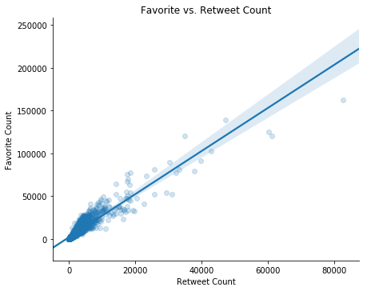

```python
# Plot scatterplot of retweet vs favorite count
sns.lmplot(x="retweet_count",
           y="favorite_count",
           data=twitter,
           size = 5,
           aspect=1.3,
           scatter_kws={'alpha':1/5})
plt.title('Favorite vs. Retweet Count')
plt.xlabel('Retweet Count')
plt.ylabel('Favorite Count');
```

### Retweet Counts:

```python
twitter.retweet_count.describe()
```

```
count     1990.000000
mean      2610.578392
std       4665.257684
min         11.000000
25%        583.000000
50%       1253.000000
75%       2971.750000
max      82598.000000
Name: retweet_count, dtype: float64
```

```python
def set_my_palette():
    sns.set()
    current_palette = sns.color_palette(my_palette)
    sns.set_palette(current_palette)
```

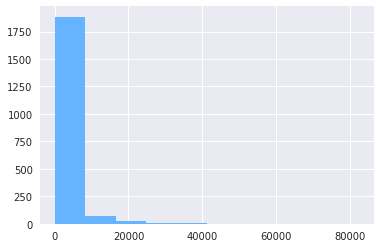

```python
my_palette = ['#66b3ff', '#00cc99', '#ff6666', '#ffff66', '#8c66ff', '#66ffd9']
set_my_palette()
twitter.retweet_count.hist();
```

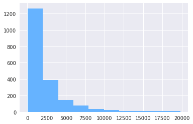

```python
twitter[twitter.retweet_count <= 20000].retweet_count.hist();
```

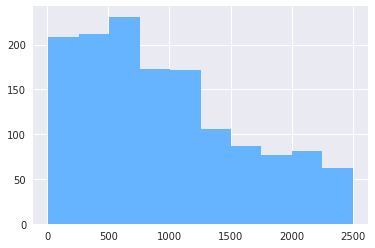

```python
twitter[twitter.retweet_count <= 2500].retweet_count.hist();
```

### Favorites Count:

```python
twitter.favorite_count.describe()
```

```
count      1990.00000
mean       8607.80603
std       12639.95152
min          77.00000
25%        1853.25000
50%        3890.00000
75%       10732.00000
max      162417.00000
Name: favorite_count, dtype: float64
```

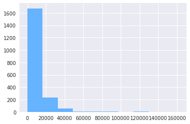

```python
twitter.favorite_count.hist();
```

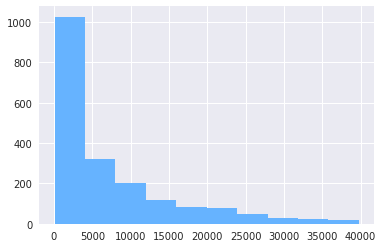

```python
twitter[twitter.favorite_count <= 40000].favorite_count.hist();
```

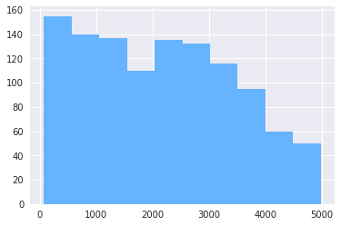

```python
twitter[twitter.favorite_count <= 5000].favorite_count.hist();
```

```python
# There are 3 outliers with a rating over 2.
# Find them to see if they are inaccurate or just unique.
twitter.loc[twitter['rating'] > 2]
```

|  | tweet_id | in_reply_to_status_id | in_reply_to_user_id | timestamp | source | text | expanded_urls | rating_numerator | rating_denominator | name | ... | p1_conf | p1_dog | p2 | p2_conf | p2_dog | p3 | p3_conf | p3_dog | dog_stage | rating |
| --- | --- | --- | --- | --- | --- | --- | --- | --- | --- | --- | --- | --- | --- | --- | --- | --- | --- | --- | --- | --- | --- |
| 409 | 810984652412424192 | NaN | NaN | 2016-12-19 23:06:23 | <a href="http://twitter.com/download/iphone" r... | Meet Sam. She smiles 24/7 &amp; secretly aspir... | https://www.gofundme.com/sams-smile,https://tw... | 24.0 | 7 | Sam | ... | 0.871342 | True | Tibetan_mastiff | 0.036708 | True | Labrador_retriever | 0.025823 | True | NaN | 3.428571 |
| 795 | 749981277374128128 | NaN | NaN | 2016-07-04 15:00:45 | <a href="https://about.twitter.com/products/tw... | This is Atticus. He's quite simply America af.... | https://twitter.com/dog_rates/status/749981277... | 1776.0 | 10 | Atticus | ... | 0.533941 | False | sunglasses | 0.080822 | False | sunglass | 0.050776 | False | NaN | 177.600000 |
| 1787 | 670842764863651840 | NaN | NaN | 2015-11-29 05:52:33 | <a href="http://twitter.com/download/iphone" r... | After so many requests... here you go.\n\nGood... | https://twitter.com/dog_rates/status/670842764... | 420.0 | 10 | NaN | ... | 0.096063 | False | accordion | 0.094075 | False | drumstick | 0.061113 | False | NaN | 42.000000 |

3 rows × 26 columns

The first instance is a rating of 24/7 which is inaccurate and I had found when looking for quality errors but decided not to fix. If we were required to fix all problems then thix tweet could be removed but I will ignore in this case. The other 2 tweets are accurate ratings that are jokes. I am more interested if the tweets with a standardized rating of below 1 decrease over time therefore I will limit the y axis from 0 to 2.

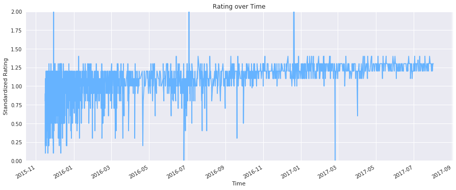

```python
# Plot standardized ratings over time with ylim of 0-2
twitter.groupby('timestamp')['rating'].mean().plot(kind='line', figsize=[15,6])
plt.ylim(0, 2)
plt.title('Rating over Time')
plt.xlabel('Time')
plt.ylabel('Standardized Rating')
plt.show;
```

Indeed it appears that overtime the frequency of ratings below 1 decreases. Before 2016-11 there many ratings below 1, while after that time there are barely any.